# Билет 4

```python
import numpy as np
import matplotlib.pyplot as plt
import matplotlib
```

### Задача 1

#### Необходимое и достаточное условие сходимости последовательности (критерий Коши)

Последовательность является фундаментальной, если $ \forall \varepsilon > 0 \ \exists N(\varepsilon) \in \mathbb{N}: \forall \ n \geqslant N, p > 0 \ | x_{N + p} - x_{n} | < \varepsilon $.

Последовательность сходится, если она является фундаментальной.

$ \Rightarrow $ Пусть $ \lim\limits_{n \to \infty} x_n = x \Rightarrow \forall \varepsilon > 0 \ \exists N(\varepsilon) \in \mathbb{N} $, т.ч. $ \forall n \geqslant N: | x_n - x | < \frac{\varepsilon}{2} $. Тогда $ \forall p > 0 | x_{n + p} - x | < \frac{\varepsilon}{2}. \Rightarrow \forall n \geqslant N \forall p > 0: |x_{n + p} - x_n| = |x_{n + p} - x + x - x_n| \leqslant |x_{n + p} - x| + |x_n - x| \leqslant \varepsilon $

$ \Leftarrow $ Пусть последовательность $ \{x_n\} $ - фундаментальная. Тогда она ограницена (по лемме 2). По теореме Больцано-Вейерштрасса выберем сходящуюсю подпоследовательность $ \{x_{k_n}\} $. Пусть $ \lim\limits_{n \to \infty} x_{k_n} = x $. Докажем, что $ x = \lim\limits_{n \to \infty} x_n $ Возьмём $ \varepsilon > 0 \ \exists N_1(\varepsilon) \in \mathbb{N}: \forall n \geqslant N_1 |x_{k_n} - x| < \frac{\varepsilon}{2} $. Поскольку $ \{x_n\} $ - фундаментальная последовательность, $ \exists N_2(\varepsilon) \in \mathbb{N}: \forall n \geqslant N, p \in \mathbb{N} |x_{n + p} - x_n| < \frac{\varepsilon}{2}. N = max\{N_1, N_2\} $. Тогда $ \forall n \geqslant N |x_n - x| = |x_n - x_{k_n} + x_{k_n} - x| \leqslant |x_{n_k} - x_n| + |x_{n_k} - x| = |x_{n+p} - x_n| + |x_{n_k} - x| < \varepsilon \Rightarrow \lim\limits_{n \to \infty} x_n = x $

### Задача 2

#### Определение, свойства и график функции $ y=ctg x $

Функция нечётная, периодическая ($ T = \pi $).

Убывает на $ \mathbb{X} $

Функция непрерывна на $ \mathbb{X} $

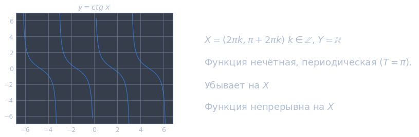

```python
x = np.linspace(- 2 * np.pi, 2 * np.pi, 200)
y = 1 / np.tan(x)
threshold = 10
y[y>threshold] = np.inf
y[y<-threshold] = np.inf

matplotlib.rcParams.update({'font.size': 18})

fig, axs = plt.subplots(1, 2, figsize=(12, 4))
axs[0].set_ylim([-7, 7])
axs[0].plot(x, y)
axs[0].set_title('$ y=ctg \ x $')

axs[1].axis('off')
axs[1].text(0, 0.02, r"""
$ X = (2\pi k, \pi + 2\pi k) \ k \in \mathbb{Z} $, $ Y = \mathbb{R} $

Функция нечётная, периодическая ($ T = \pi $).

Убывает на $ X $

Функция непрерывна на $ X $
""")
plt.show()
```

### Задача 3

#### Определение - число $ M $ не является точной верхней гранью множества $ \{x\} $

Число $ M $ не является точной верхней границей множества $ \{x\} $, если $ \exists \ x \in \{x\}: x > M $

### Задача 4

#### Дать определение по Коши: неверно, что $ \lim\limits_{x \to -\infty} f(x) = b $

$ \lim\limits_{x \to -\infty} f(x) \not = b \Leftrightarrow \exists \varepsilon > 0 \ \forall \delta = \delta(\varepsilon) > 0 \ \forall x \in X: x < -\delta \Rightarrow |f(x) - b| > \varepsilon $

### Задача 5

#### Дать определение: $ \phi(x) = \bar{o}(\psi(x)), x \to a $

Если $ \exists \lim\limits_{x \to a} \frac{\phi(x)}{\psi(x)} = 0 $, то $ \phi(x) = \bar{o}(\psi(x)), x \to a $